# 智能制造系统设计 · 第 5 章专题

深度运筹与图神经网络（补充讲）

刘训臣

山东科技大学 机械电子工程学院

# 第〇部分 · 课程介绍与本讲定位

- 本讲是第 5 章“设计方法”的专题补充：从算法基础到图神经网络、深度运筹与 PyTorch
- 主线：问题 → 数据 → 图 → 模型 → 评价，最后落到企业齿轮缺陷检测
- 与第 4 讲“设计对象”、第 6 讲“8D 与课程设计”前后衔接
- **产教融合**：企业缺陷图像数据与企业验收指标贯穿全讲

## 为什么单独讲“方法”

> **前三章回答“设计什么、约束是什么、谁承载”，本章回答“怎么算”。**
- 企业不缺数据，缺的是从数据里找“断点”的工具；算法不是目的，是找关系、做判断的手段
- 深度运筹学＝运筹学定目标与约束＋复杂网络建关系＋图深度学习找满意解
- 本讲四个内容块：算法基础、图神经网络、深度运筹学、PyTorch 实践
- 一条企业主线：齿轮缺陷检测，从 4% 漏检降到 1% 以内

## 教学进度 · 本讲在课程中的位置

| 次 | 模块 | 主题 |
| --- | --- | --- |
| 3 | 3.1～3.4 | 设计目标：质量、效率、安全、成本——发现问题与设计约束 |
| 4 | 4.1～4.6 | 设计对象：ERP、MES、APS、WMS、PLM、CRM——约束由谁承载 |
| **5** | **5.1～5.4** | **设计方法：算法、图神经网络、深度运筹学、PyTorch——本讲专题** |
| 6 | 6.1～6.2 | 设计过程：8D 报告与调研、蓝图、实施、上线、持续改进 |

- 第 3 章给约束，第 4 章给对象，本章给方法，第 6 章把三者组织成可交付的设计过程
- 本章支撑课程目标 3（以深度运筹学为底层逻辑建立系统复杂网络模型），对应毕业要求指标点 10.1
- 本讲只讲 90 分钟的“方法与落地”，其余学时用于上机与课程设计

## 本章要回答的三个问题

| 问题 | 本讲回答 | 落到哪一页 |
| --- | --- | --- |
| 选什么算法？ | 任务决定指标，数据决定模型；先问“要回答什么问题” | 算法基础、选型五问 |
| 怎么把系统变成图？ | 节点、边、权重、约束；复杂网络与图神经网络 | 图神经网络、深度运筹学 |
| 怎么证明模型能用？ | 漏检率、误检率、节拍；企业验收指标 | PyTorch 实践、评价指标 |

- 三个问题对应“算法—建模—评价”，缺一个都落不了地
- 企业最常问的不是“模型多先进”，而是“漏检多少、节拍够不够、能不能解释”
- 本讲每个内容块结束都回到这三个问题

## 产教融合 · 本讲企业真题：齿轮缺陷检测

> **企业场景：**合作企业齿轮产线人工目检漏检率约 4%、单件 8 s；目标漏检率≤1%、误检率≤3%、单件节拍≤2 s。

| 企业真实问题 | 本讲工具 | 学生产出 |
| --- | --- | --- |
| 缺陷样本约 2000 张、5 类；小样本、类别不均、节拍要求高 | 算法选型、GCN/GNN、深度运筹、PyTorch | 缺陷检测模型＋mAP/漏检率报告（作业 2） |

- **教案对应：**第五章 5.1～5.4；**企业参与：**质量部提供脱敏图像与标注规范，算法工程师线上点评
- **验收：**漏检率≤1%、误检率≤3%、单件推理≤2 s；报告附 3 个失败样本的原因分析

## 本讲伦理与社会落点

- **算法与源代码出口管制**：《出口管制法》将源代码、算法等技术资料列入管制范围，核心技术不能受制于人
- **数据安全与员工隐私**：缺陷图像、操作影像的采集范围、保存期限、查看权限要写进制度
- **模型偏见与问责**：某类缺陷系统性漏检，是数据问题、模型问题还是验收问题，要能说清
- **企业指标 vs 学术指标**：mAP 高不等于漏检低，验收要回到企业节拍与缺陷定义

## 本讲 90 分钟怎么安排

| 部分 | 内容 | 分钟 |
| --- | --- | --- |
| 第〇部分 | 定位、企业真题、伦理落点 | 8 |
| 第一部分 | 算法基础：术语、范式、常见算法、神经网络 | 18 |
| 第二部分 | 图神经网络：图数据、嵌入、GCN、GAT | 22 |
| 第三部分 | 深度运筹学：复杂网络、中心性、框架、排产 | 18 |
| 第四部分 | PyTorch：环境、训练、YOLO、评价 | 18 |
| 第五、六部分 | 例题讨论、小结与作业 | 6 |

- 四个内容块按“算法→图→运筹→落地”递进，每块结束回到企业真题
- 例题不单独占大段时间，放在对应内容块后随讲随练
- 上机与企业数据训练放到课后，课上只保证“听得懂、跑得通、会验收”

## 推导留给 AI：课程介绍与本讲定位

- 为什么说“深度运筹学＝运筹学＋复杂网络＋图学习”，三部分各自解决什么？
- 企业缺陷检测的“小样本、类别不均”分别会带来什么后果？
- 漏检率、误检率、mAP 三个指标，为什么不能互相替代？
- 如果只允许改一个环节，你会先改数据、模型还是验收标准？

# 第一部分 · 算法基础

- 机器学习是什么：从数据里找规律，再用规律做预测
- 三类学习范式：监督、无监督、半监督与强化
- 常见算法：回归、分类、聚类、树模型、神经网络
- 落到企业：先定任务与指标，再选算法，不追新

## 机器学习：从数据到规律

> **机器学习＝用数据估计一个映射 $f$，让它在没见过的样本上仍然好用。**
- 三个要素：数据（样本与标签）、模型（假设空间）、评价（损失与指标）
- 两类目标：分类（输出类别）与回归（输出数值）
- 核心矛盾：训练误差小不等于泛化好；过拟合就是“背答案”
- 企业落点：缺陷分类是分类问题，节拍预测、寿命预测是回归问题

## 基本术语：先把话说清

| 术语 | 含义 | 企业例子 |
| --- | --- | --- |
| 数据集 | 样本的集合，分训练集/验证集/测试集 | 2000 张缺陷图像，按 7∶1.5∶1.5 划分 |
| 样本/示例 | 一个对象 | 一张齿轮齿面图像 |
| 特征 | 描述样本的属性 | 灰度、纹理、边缘、缺陷面积 |
| 标签 | 样本的正确答案 | 划痕、磕碰、缺齿、锈蚀、正常 |
| 泛化 | 对未见样本的表现 | 新批次、新光照下的漏检率 |

- 特征工程决定上限，模型只是逼近上限；深度学习的价值是自动学特征
- 训练集、验证集、测试集不能混；测试集只能用一次
- 标签质量比模型复杂度更重要：标错的样本会把模型带偏

## 三类学习范式

| 范式 | 数据条件 | 典型任务 | 企业例子 |
| --- | --- | --- | --- |
| 监督学习 | 有标签 | 分类、回归 | 缺陷分类、齿厚预测 |
| 无监督学习 | 无标签 | 聚类、降维、异常检测 | 客户分群、设备异常 |
| 半监督学习 | 少量标签＋大量无标签 | 分类 | 标注成本高时扩样本 |
| 强化学习 | 与环境交互、奖惩 | 序贯决策 | 排产策略、机器人控制 |

- 企业里 80% 的落地是监督学习：有历史标签，先把分类/回归做扎实
- 无监督常用于“没有标签但想找异常”，结果是线索不是结论
- 强化学习门槛最高：需要仿真环境、奖励设计和安全约束

## 常见算法全景

| 任务 | 代表算法 | 优点 | 局限 |
| --- | --- | --- | --- |
| 回归 | 线性回归、岭回归、梯度增强 | 可解释、快 | 非线性弱 |
| 分类 | 逻辑回归、SVM、KNN、随机森林 | 小样本可用 | 高维图像弱 |
| 聚类 | K-means、层次聚类、DBSCAN | 无需标签 | 要定簇数/参数 |
| 降维 | PCA、t-SNE | 可视化、去冗余 | 信息有损 |
| 深度学习 | CNN、YOLO、GNN | 自动学特征 | 要数据、算力 |

- 传统算法是基线：先跑逻辑回归/SVM，知道“简单方法能做到什么程度”
- 深度学习不是万能：小样本、可解释要求高的场景，传统方法更稳
- 算法选择看三件事：数据量、任务类型、验收指标

## 线性回归与逻辑回归

**线性回归**：$y=w^{\mathrm{T}}x+b$，用最小二乘最小化 $\sum(y_i-\hat y_i)^2$。

**逻辑回归**：$p=\sigma(w^{\mathrm{T}}x+b)$，$\sigma(z)=1/(1+e^{-z})$，输出 0～1 的概率。

- 线性回归做数值预测：齿厚、节拍、寿命；逻辑回归做二分类：合格/不合格
- 逻辑回归的系数可解释：特征每增加 1 个单位，对数几率变化多少
- 线性模型是基线：非线性模型至少要比它好，否则不值得上

## SVM 与 KNN

- **SVM**：找最大间隔超平面；线性不可分时用核函数升维，常用 RBF 核
- **KNN**：看最近的 $k$ 个邻居投票；$k$ 小易受噪声，$k$ 大易欠拟合
- SVM 适合小样本、高维；KNN 适合样本少、特征尺度可比的场景
- 两者都要先做特征标准化，否则距离/间隔被大量纲特征支配

## K-means 与降维

- **K-means**：先定 $k$ 个中心，反复“分配—更新”，目标是最小化簇内平方和
- 缺点：要预先定 $k$、对初值敏感、只适合球形簇；改进：K-means++、肘部法
- **PCA**：把相关特征投影到方差最大的方向，做去冗余与可视化
- **t-SNE**：非线性降维，适合看类别是否可分，不适合解释坐标轴

## 决策树与集成学习

- **决策树**：按特征阈值不断划分，节点纯度用信息增益/基尼指数衡量；可解释，但易过拟合
- **随机森林**：多棵树投票，袋外样本估计泛化误差；稳、抗噪
- **梯度增强**：逐步拟合残差，精度高；要调学习率、树深、早停
- 企业场景：小样本、表格型工艺参数，树模型往往比深度学习更稳

## 朴素贝叶斯与符号回归

- **朴素贝叶斯**：假设特征条件独立，用先验×似然算后验；文本分类经典，小样本快
- 独立性假设常不成立，概率值只能排序、不能当真实概率
- **符号回归**：不预设函数形式，搜索能拟合数据的解析表达式
- 符号回归的价值是“给出公式”：$y=f(x_1,x_2)$，比黑箱模型更适合写进工艺文件

## 神经网络：神经元模型

> **一个神经元＝加权求和＋阈值＋激活函数。**

$$y=f\left(\sum_{i=1}^{n}w_i x_i-\theta\right)$$

- $x_i$ 为输入，$w_i$ 为连接权值，$\theta$ 为阈值，$f$ 为激活函数
- 多层堆叠＋非线性激活，才能逼近复杂函数；没有激活，多层等价于一层
- 训练就是调 $w_i$ 与 $\theta$，让损失函数变小

## 激活函数：给网络加非线性

| 函数 | 表达式 | 特点 | 适用 |
| --- | --- | --- | --- |
| Sigmoid | $1/(1+e^{-z})$ | 输出 0～1，两端饱和 | 二分类输出层 |
| Tanh | $(e^z-e^{-z})/(e^z+e^{-z})$ | 零中心，仍饱和 | 浅层网络 |
| ReLU | $\max(0,z)$ | 计算快，缓解梯度消失 | 隐藏层默认 |
| Softmax | $e^{z_i}/\sum_j e^{z_j}$ | 输出概率分布 | 多分类输出层 |

- 隐藏层优先 ReLU；输出层按任务选 Sigmoid（二分类）或 Softmax（多分类）
- 饱和区梯度接近 0，深层网络容易“学不动”
- 激活函数不是越复杂越好，先保证训练稳定

## 前向传播与反向传播

- **前向**：输入逐层算到输出，得到预测值 $\hat y$ 与损失 $L$
- **反向**：用链式法则从输出往回算每个参数的梯度 $\partial L/\partial w$
- **更新**：$w\leftarrow w-\eta\,\partial L/\partial w$，$\eta$ 为学习率
- 一轮＝前向＋反向＋更新；批量大小、学习率、迭代轮数是三个基本超参数

## 过拟合与正则化

> **过拟合＝训练集很好、新样本很差；判断靠验证集，不靠训练损失。**
- 表现：训练损失持续降，验证损失先降后升
- 手段：更多数据、数据增强、简化模型、L2 正则、Dropout、早停
- 企业里最有效的是“更多真实数据＋更严的标注”，不是换更深的网络
- 小样本时用交叉验证，别用一次划分下结论

## 评价指标：分类任务

| 指标 | 公式 | 含义 |
| --- | --- | --- |
| 准确率 | $(TP+TN)/(TP+TN+FP+FN)$ | 全对的比例，类别不均时会骗人 |
| 精确率 | $TP/(TP+FP)$ | 报出来的有多少是真的 |
| 召回率 | $TP/(TP+FN)$ | 真的有多少被报出来 |
| F1 | $2PR/(P+R)$ | 精确率与召回率的调和平均 |

- 缺陷检测最怕漏检：召回率（1−漏检率）优先，再看误检率
- 类别不均时，准确率可能很高但漏检很多，必须看混淆矩阵
- 企业验收要写清“漏检率、误检率、节拍”三个数，不能只写准确率

## 评价指标：回归任务

- **MAE**：$\frac1n\sum|y_i-\hat y_i|$，与目标同单位，直观
- **MSE/RMSE**：$\frac1n\sum(y_i-\hat y_i)^2$，放大大误差，优化常用
- **$R^2$**：$1-\sum(y_i-\hat y_i)^2/\sum(y_i-\bar y)^2$，解释了多少方差
- 回归指标要结合业务容差：齿厚差 0.01 mm 和 0.1 mm 的代价完全不同

## 企业案例：传统特征＋SVM 与 YOLO 怎么选

| 维度 | 传统特征＋SVM | YOLO 类检测模型 |
| --- | --- | --- |
| 数据需求 | 几十到几百张可起步 | 千张以上，需标注框 |
| 精度 | 受特征设计限制 | 高，能定位缺陷 |
| 节拍 | 快，适合简单特征 | GPU 上可到毫秒级 |
| 可解释 | 特征明确，易解释 | 黑箱，需可视化 |
| 维护 | 换产品要重设特征 | 换产品要重新标注训练 |

- 小样本、规则明确的缺陷先用传统特征＋SVM 做基线
- 缺陷形态多、要定位、数据够，再上 YOLO
- 企业验收看漏检率与节拍，不看模型名字

## 算法选型五问

1. **任务是什么**：分类、回归、聚类还是序贯决策？
2. **数据够不够**：样本量、标签质量、类别是否均衡？
3. **指标是什么**：漏检率、误检率、节拍还是可解释？
4. **能不能维护**：换产品、换光照、换批次要不要重训？
5. **算力与部署**：云端、边缘还是工控机，延迟预算是多少？

## 推导留给 AI：算法基础

- 为什么“训练集准确率 99%、测试集 80%”说明过拟合，而不是数据出错？
- 类别不均时，准确率、召回率、F1 哪个最能反映缺陷检测的真实水平？
- 小样本缺陷检测，为什么“数据增强＋迁移学习”常比“换更深的网络”有效？
- 传统特征＋SVM 与 YOLO，各自的失效场景是什么？

# 第二部分 · 图神经网络

- 图数据：节点、边、权重，描述“谁和谁有关系”
- 图嵌入：把节点映射成低维向量，保留结构信息
- 图卷积：邻居聚合＋特征变换，GCN、GraphSAGE、GAT
- 落到企业：系统关系图、缺陷传播图、排产约束图

## 图无处不在

| 场景 | 节点 | 边 |
| --- | --- | --- |
| 社交网络 | 用户 | 关注/好友 |
| 交通网络 | 路口/站点 | 道路/线路 |
| 电网 | 变电站/设备 | 输电线路 |
| 分子结构 | 原子 | 化学键 |
| 企业系统 | 订单/工单/设备/物料 | 流转/依赖/约束 |

- 图的本质是“关系”：很多制造问题不是算单个对象，而是算对象之间怎么影响
- 企业系统里，订单、工单、设备、物料天然构成一张多尺度网络
- 图学习就是把“关系”变成可计算的向量

## 图的特殊性：为什么 CNN 不够用

- **非规则**：每个节点的邻居数不同，没有固定的 3×3 邻域
- **无固定顺序**：邻居没有天然的左上到右下顺序，换编号结果应不变
- **非独立同分布**：节点之间有关联，不能假设样本独立
- **规模大且稀疏**：百万节点、平均度很小，矩阵不能稠密存储

> **CNN 处理欧氏空间（图像、语音），GNN 处理非欧空间（图）。**

## 图的三类任务

| 任务 | 输出 | 企业例子 |
| --- | --- | --- |
| 节点预测 | 每个节点的类别/数值 | 设备故障风险、工位瓶颈 |
| 边预测 | 两节点是否有边/权重 | 推荐、供应链关系、缺陷传播 |
| 图预测 | 整张图的属性 | 订单是否延期、批次是否合格 |

- 节点预测看局部：聚合邻居后分类
- 边预测看两节点的表示是否“匹配”
- 图预测要先“读出”（readout）整图表示，再做分类/回归

## GNN 的通用流程

1. **建图**：定节点、边、权重、方向
2. **初始化**：节点特征（数值、类别、文本嵌入）
3. **消息传递**：聚合邻居 → 变换 → 激活，重复 $K$ 层
4. **读出**：节点表示 → 图表示（池化/注意力）
5. **任务头**：分类/回归/链接预测，配损失训练

## 端到端学习

> **端到端＝从原始输入直接学到输出，中间不靠手工特征。**
- 传统流程：特征工程 → 模型 → 输出，特征设计决定上限
- 端到端：输入 → 网络 → 输出，特征由网络自己学
- 优点：省人工、能学复杂模式；缺点：要数据、可解释性弱
- 图上的端到端：输入邻接矩阵＋节点特征，输出节点/图标签

## 图嵌入：Word2Vec 的思路

- 词嵌入：把词映射成低维向量，语义相近的词向量也相近
- **CBOW**：用上下文预测中心词；**Skip-gram**：用中心词预测上下文
- 训练目标：让共现概率大的词对向量更接近
- 迁移到图：把“节点”当“词”，把“随机游走序列”当“句子”

## DeepWalk：随机游走＋词向量

- 第一步：从每个节点出发做随机游走，得到节点序列
- 第二步：把序列当句子，用 Skip-gram 学节点向量
- 性质：相邻节点在向量空间更接近；无需标签，属于无监督
- 局限：只保留“共现”，不区分边类型与方向；对稀疏图不稳定

## 异质图、超图与动态图

| 类型 | 特点 | 企业例子 |
| --- | --- | --- |
| 异质图 | 节点/边有多种类型 | 订单—工单—设备—物料 |
| 二分图 | 两类节点，边只跨类 | 客户—产品、工位—工序 |
| 超图 | 一条超边连多个节点 | 一个订单涉及多个工序 |
| 动态图 | 结构随时间变化 | 排产每天重排、设备状态变化 |

- 异质图要按类型分别聚合，或先转成多张同质图
- 超图适合“一对多”关系，普通图要拆成多条边
- 动态图要把时间作为额外维度，不能只取一个快照

## 图卷积的两条路线

| 路线 | 做法 | 优点 | 局限 |
| --- | --- | --- | --- |
| 空域 | 直接在邻居上定义聚合 | 直观、灵活、易扩展 | 理论支撑弱 |
| 谱域 | 用拉普拉斯矩阵做图傅里叶变换 | 理论清晰 | 计算重、依赖全图 |

- 空域：GCN、GraphSAGE、GAT，工业界主流
- 谱域：从卷积定理出发，把图信号变到频域再滤波
- 两条路线不是对错，是“直观灵活”与“理论清晰”的取舍

## 空域 GCN：邻居聚合

> **每个节点的新表示＝自己的旧表示＋邻居旧表示的加权平均，再过一层变换。**

$$h_v^{(k)}=\sigma\left(W^{(k)}\sum_{u\in\mathcal N(v)\cup\{v\}}\frac{1}{\sqrt{d_u d_v}}h_u^{(k-1)}\right)$$

- $\mathcal N(v)$ 为邻居集合，$d_u,d_v$ 为节点度，$W$ 为可学习权重
- 除以 $\sqrt{d_ud_v}$ 是归一化：度大的节点不至于“声音太大”
- 堆 $K$ 层，每个节点就能看到 $K$ 跳以内的邻居

## 归一化邻接矩阵

- 邻接矩阵 $A$：$A_{ij}=1$ 表示 $i,j$ 有边；加自环 $\tilde A=A+I$
- 度矩阵 $D$：对角元 $D_{ii}=\sum_j\tilde A_{ij}$
- 归一化：$\hat A=D^{-1/2}\tilde A D^{-1/2}$，每行权重被度“压平”
- 一层传播就是 $\hat A X W$，$X$ 为节点特征矩阵，$W$ 为权重

## 手算一层 GCN：题干

**图**：4 个节点围成环 1—2—3—4—1，每个节点加自环，度均为 3。

**特征**：$x_1=(1,0)$，$x_2=(0,1)$，$x_3=(1,1)$，$x_4=(0,0)$；权重 $W=I$，激活 ReLU。

**求**：$\hat A X W$ 与 $H=\mathrm{ReLU}(\hat A X W)$。

- 提示：$\hat A=\frac13\tilde A$（因为每个节点度都是 3）
- 先算每个节点“自己＋邻居”的特征和，再除以 3

## 手算一层 GCN：解答

$$\tilde A=\begin{bmatrix}1&1&0&1\\1&1&1&0\\0&1&1&1\\1&0&1&1\end{bmatrix},\quad \hat A X=\frac13\begin{bmatrix}1&1\\2&2\\1&2\\2&1\end{bmatrix}$$

$$H=\mathrm{ReLU}(\hat A X W)=\begin{bmatrix}1/3&1/3\\2/3&2/3\\1/3&2/3\\2/3&1/3\end{bmatrix}$$

- 节点 2 的邻居特征和最大（2,2），节点 1 最小（1,1）；聚合后节点 2 仍最强
- 节点 4 原本是 (0,0)，聚合后得到 (2/3,1/3)，说明它“吸收”了邻居信息

## GraphSAGE：采样＋聚合

- 动机：全图聚合在大图上太慢，且新节点加入要重算
- 做法：对每个节点固定采样 $k$ 个邻居，选聚合函数（mean/max/LSTM）
- 优点：归纳式，能为没见过的新节点生成表示；可小批量训练
- 代价：采样带来随机性，聚合函数选择影响效果

## 谱域 GCN：拉普拉斯与卷积定理

- 拉普拉斯矩阵 $L=D-A$，对称半正定，可分解 $L=U\Lambda U^{\mathrm T}$
- 图傅里叶变换：$\hat x=U^{\mathrm T}x$，把信号投影到频域
- 卷积定理：空域卷积＝频域相乘，于是图卷积＝$U\,g_\theta(\Lambda)\,U^{\mathrm T}x$
- 问题：$U$ 要全图特征分解，$O(n^2)$ 内存、$O(n^3)$ 计算；用切比雪夫多项式近似降复杂度

## GAT：给邻居加注意力

- 动机：不同邻居的重要性不同，固定权重不够
- 做法：对每条边算注意力系数 $\alpha_{ij}$，再按 $\alpha$ 加权聚合
- 多头注意力：多组 $\alpha$ 并行，拼接或平均，稳定训练
- 优点：可解释（看注意力权重）、对噪声邻居更鲁棒

## GRNN 与层析池化

- **GRNN**：在图上传隐藏状态，像 RNN 一样迭代，适合动态图/时序图
- **层析池化**：多级网络信息汇聚，把不同尺度的子图表示合并
- 池化解决“图太大、层次太多”的问题：先局部聚类，再逐层读出
- 企业落点：多尺度系统（订单—工单—工序—设备）需要分层表示

## 图预测与读出

- 节点表示 → 图表示：求和、平均、最大池化，或注意力加权
- 读出要“置换不变”：节点换顺序，图表示不变
- 图分类/回归：图表示接全连接层，输出类别或数值
- 企业例子：一张“订单图”是否延期，一张“批次图”是否合格

## 应用一：图神经网络预测裂纹分形维数

- 裂纹形态不规则，欧氏几何难描述；用树结构刻画不同尺度的分支
- 节点＝裂纹段/分支点，边＝连接关系，特征＝长度、角度、宽度
- GNN 聚合多尺度特征，回归分形维数；比手工特征更稳
- 关键：建图规则要统一，否则同一裂纹不同人建出不同的图

## 应用二：CT 缺陷识别与企业系统断点

| 场景 | 建图方式 | 任务 |
| --- | --- | --- |
| 复合材料 CT | 缺陷区域为节点，空间相邻为边 | 缺陷分类/分割 |
| 企业系统 | 订单/工单/设备/物料为节点，流转为边 | 断点识别、延期预测 |
| 排产 | 工单为节点，工序先后为边 | 瓶颈预测、插单影响 |

- CT 缺陷：跨尺度提取气泡、裂纹，树结构比像素网格更接近材料劣化本质
- 企业系统：断点不是单点故障，会沿关系边传播；图能算“影响半径”
- 排产：把约束画成边，GNN 预测瓶颈，运筹学做局部优化

## 推导留给 AI：图神经网络

- 为什么 GNN 的结果要和节点编号无关？归一化邻接矩阵起了什么作用？
- 层数越多，节点看到的邻居越远，但为什么太深反而变差？
- GraphSAGE 的“采样”与 GAT 的“注意力”，各自解决什么问题？
- 企业系统断点图，节点和边应该怎么定？边权用什么？

# 第三部分 · 深度运筹学

- 背景：数据爆炸之后，创新断点在哪里
- 复杂网络：钱学森定义、五个特性、中心性与群聚系数
- 线性规划：三要素与标准型、图解法、单纯形、对偶与影子价格、整数规划
- 深度运筹学：运筹学定目标，复杂网络建关系，图学习找满意解
- 落到企业：排产图建模、插单影响、瓶颈预测

## 背景：数据爆炸与创新断点

> **硬件红利之后，企业面临数据爆炸带来的创新焦虑；关键是找到系统的“断点”。**
- 数据“躺”在机房：有采集、没分析，缺乏大海捞针的工具
- 理论“散装”：质量、IE、安全、成本、信息系统各讲各的，缺统一底层逻辑
- 内卷：直觉/经验式创新困在产品本身，突破不了同质化
- 深度运筹学的回答：用关系（图）把数据组织起来，在关系上找断点

## 复杂网络：钱学森的定义

> **具有自组织、自相似、吸引子、小世界、无标度中部分或全部性质的网络，称为复杂网络。**
- 复杂网络不是“很复杂的图”，而是统计性质特殊的一类网络
- 五个性质不是每个网络都有，有其中一部分就可以叫复杂网络
- 制造系统、供应链、企业信息系统都可以看成复杂网络
- 研究复杂网络，就是研究“关系结构”如何影响系统行为

## 动图：蚁群怎样在网络上找到最短路

> 上一页是钱学森的定义；这一页给一个看得见的例子——没有指挥，蚁群也能收敛到最短路径。

[figure not shown]

- 每只蚂蚁只看得到眼前几厘米：留信息素、跟信息素走，**没有全局地图**
- 短路径上的信息素来回趟得多、浓度升得快，于是被更多蚂蚁选中——**正反馈**
- 结果：群体行为在图上收敛到一条近似最短路，这是**分布式寻优**
- 对应算法：蚁群优化（ACO）就是把这个过程写成状态转移概率与信息素更新式
- 与本讲接口：ACO 是启发式，LP／IP 是精确解，GNN 学的是图上的模式——三类方法互补

**结论：个体只按局部规则行动，群体却能解出全局最短路——这是复杂网络上“涌现”的最小例子。**

## 最短路：Dijkstra 的贪心

> 上一页的蚁群靠信息素“涌现”出路径；这一页给精确算法——边权已知时，最短路怎么算。
- 最短路：从源点到某点的所有路径里，边权之和最小的那条；边权可以是时间、距离、运费
- Dijkstra 三步：①源点记 0、其余记 $\infty$；②每轮挑未确定点里距离最小的，标为已确定；③用它松弛邻居
- 重复“挑最小＋松弛”共 $V$ 次，全部确定；复杂度 $O\big((V+E)\log V\big)$（邻接表＋二叉堆）
- 前提：边权非负；出现负权要改用 Bellman-Ford
- AGV 路网算例：6 个路口、9 条通道（单位分钟），求 0 号到 4 号
- 手算：$0\to2=9$、$0\to2\to5=11$、$0\to2\to5\to4=20$；对比 $0\to1\to3\to4=7+15+6=28$、$0\to2\to3\to4=9+11+6=26$

**结论：Dijkstra 每轮锁定一个最近点再松弛邻居；贪心能成立，靠的就是边权非负。**

## 运行例子（三）：dijkstra 求最短路

```python
import numpy as np
from scipy.sparse import csr_matrix
from scipy.sparse.csgraph import dijkstra

# 6 个路口、9 条通道，边权＝通行时间（分钟）
E = [(0,1,7),(0,2,9),(0,5,14),(1,2,10),(1,3,15),
     (2,3,11),(2,5,2),(3,4,6),(4,5,9)]
n = 6
M = np.full((n, n), np.inf)
for u, v, w in E:
    M[u, v] = M[v, u] = w

d, pred = dijkstra(csr_matrix(M), indices=0,
                   return_predecessors=True)
print("dist:", [round(float(x), 1) for x in d])

t, path = 4, []
while t >= 0:
    path.append(int(t)); t = int(pred[t])
print("0→4:", list(reversed(path)), round(float(d[4]), 1))
```

```
dist: [0.0, 7.0, 9.0, 20.0, 20.0, 11.0]
0→4: [0, 2, 5, 4] 20.0
```

- 输出第一行是 0 号到各点的最短时间；第二行是到 4 号的路径与总时长
- 与上页手算一致：$0\to2\to5\to4=9+2+9=20$ 分钟，比绕行少 6–8 分钟
- `return_predecessors=True` 返回前驱数组，顺着前驱回溯就得到路径——最短路不只知道“多远”，还知道“怎么走”

**结论：最短路一跑，距离与路径一起出来；图上的“怎么走”就是从源点回溯前驱。**

## 图：路网与最短路

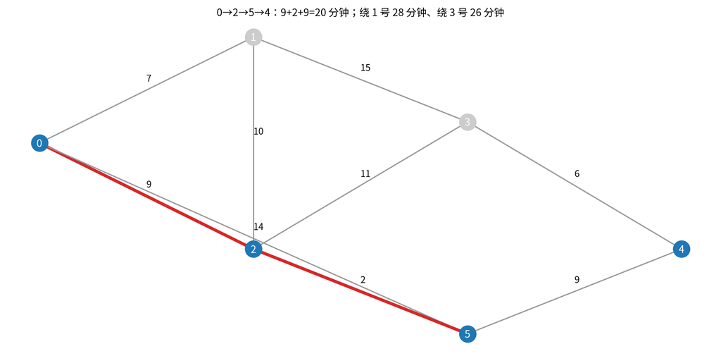

**结论：图一画出来，“最短路”就从一串数字变成一条看得见的路线。**

## 五个特性

| 特性 | 含义 | 制造例子 |
| --- | --- | --- |
| 自组织 | 无外部指令形成有序结构 | 车间自组织班组、订单自发聚簇 |
| 自相似 | 局部与整体结构相似 | 多级 BOM、分形裂纹 |
| 吸引子 | 系统趋向的稳态 | 产线稳定节拍、库存稳态 |
| 小世界 | 平均路径短、群聚高 | 供应链六度连接 |
| 无标度 | 度分布幂律，少数枢纽节点 | 关键设备、核心供应商 |

- 小世界与无标度最常用：一个管“传播快”，一个管“枢纽关键”
- 制造系统的“枢纽”往往是瓶颈设备或核心供应商，失效影响大
- 自相似对应多尺度：订单—工单—工序—动作

## 度与度分布

- 度 $k_i$：节点 $i$ 的边数；平均度 $\langle k\rangle=2E/N$
- 度分布 $P(k)$：随机选一个节点，度恰好为 $k$ 的概率
- 随机网络：度分布近似泊松，集中在平均度附近
- 无标度网络：$P(k)\sim k^{-\gamma}$，少数枢纽节点度很大

> **看一个网络是不是无标度，先画度分布的双对数图。**

## 四种中心性

| 中心性 | 回答的问题 | 计算要点 |
| --- | --- | --- |
| 度中心性 | 谁连接最多 | 归一化度 $k_i/(N-1)$ |
| 特征向量中心性 | 谁连接的人重要 | 邻接矩阵最大特征值对应特征向量 |
| 介数中心性 | 谁在最短路径上最忙 | 经过该节点的最短路径比例 |
| 紧密中心性 | 谁到所有人最快 | 到其他节点平均最短距离的倒数 |

- 度中心性看“数量”，特征向量看“质量”，介数看“桥梁”，紧密看“速度”
- 制造系统：介数高的设备/工序是瓶颈，失效影响面大
- 选哪个中心性，取决于你要回答“谁关键”还是“谁忙”

## 群聚系数

- 节点 $i$ 的群聚系数：邻居之间实际连边数 ÷ 可能连边数
- 整个网络：所有节点群聚系数的平均
- 高群聚＝“朋友的朋友也是朋友”，局部抱团
- 小世界网络＝高群聚＋短平均路径；制造集群、供应链圈层常见

## 典型网络：随机、小世界、无标度

| 网络 | 生成规则 | 度分布 | 典型现象 |
| --- | --- | --- | --- |
| 随机网络 | 每对节点以概率 $p$ 连边 | 泊松 | 平均路径短、群聚低 |
| 小世界 | 规则网络加少量随机重连 | 近似泊松 | 高群聚、短路径 |
| 无标度 | 增长＋优先连接 | 幂律 | 少数枢纽、抗随机故障弱 |

- 无标度网络对随机故障鲁棒，但对枢纽节点攻击脆弱
- 供应链、互联网、社交网络常呈无标度
- 制造系统设计要识别枢纽，做冗余与备份

## 层析网络与异构网络

- **层析网络**（多尺度/多维）：不同尺度各一层，层间有连接；跨尺度建模的利器
- **异构网络**：节点/边有多种类型；处理方式一是拆成多张同质图，二是端到端学图嵌入
- 制造系统天然多层：企业层—车间层—设备层—部件层
- 跨层传播：设备故障如何影响订单交付，要沿层间边追踪

## 运筹学回顾：优化三要素

> **运筹学＝在约束下优化目标；三要素是决策变量、目标函数、约束条件。**
- 决策变量：排产里的工单顺序、设备分配、班次安排
- 目标函数：交期延误最小、换型次数最少、利用率最高
- 约束：设备能力、工序先后、模具数量、人员班次、交期
- 经典方法：线性规划、整数规划、约束规划、启发式、元启发式

## 线性规划：三要素与标准型

> 上一页把优化拆成三要素；这一页把它写成线性规划的式子，并定下算例。
- 决策变量：$x_1$ 齿轮件数、$x_2$ 链轮件数，单位百件
- 目标：$\max z=3x_1+5x_2$（万元，单件利润 3 与 5 万元/百件）
- 约束：$2x_1+4x_2\le100$（机加工 100 h）、$3x_1+2x_2\le90$（装配 90 h）、$x_1,x_2\ge0$
- 标准型：$\max c^{\mathsf T}x$，s.t. $Ax\le b$，$x\ge0$；加松弛变量 $x_3,x_4$ 变成等式
- 判“是不是线性”：目标与约束都只含变量的一次项，不出现乘积、平方与 $\max/\min$ 嵌套

| 要素 | 排产里的对应 | 本例 |
| --- | --- | --- |
| 决策变量 | 做多少、做哪个、先做谁 | 齿轮、链轮各多少百件 |
| 目标函数 | 利润最大、延误最小 | $3x_1+5x_2$ 最大 |
| 约束条件 | 设备、工时、模具、交期 | 机加工 100 h、装配 90 h |

**结论：三要素写成一次式的组合，就是线性规划；松弛变量把“≤”变成标准型的“＝”。**

## 图解法：可行域与角点

> 上一页定了模型；两个变量可以直接画出来看，这一页用图解法求最优。
- 每条约束在平面 $x_1$—$x_2$ 上是一条直线，取满足不等号的一侧，交集就是**可行域（凸多边形）**
- 逐个求顶点：$(0,0)$ → $z=0$；$(30,0)$ → $z=90$；$(0,25)$ → $z=125$
- 第四点由两约束联立：$2x_1+4x_2=100$、$3x_1+2x_2=90$ → $x_1=20$、$x_2=15$，$z=3\times20+5\times15=135$
- 等值线 $3x_1+5x_2=z$ 斜率为 $-3/5$，向 $z$ 增大的方向平移，**最后离开可行域的顶点**就是最优解
- 定理：线性规划若存在最优解，必在可行域顶点取得（顶点有限，可枚举）

**结论：两个变量用图解就够了——把等值线推到最后一个顶点，$(20,15)$、$z=135$ 万元。**

## 单纯形法：沿顶点走两步

> 图解法只能看两个变量；这一页给出高维可用的算法——沿边从一个顶点走到更好的顶点。
- 思路：从某个顶点出发，沿可行域的边走到相邻的、目标更好的顶点，直到没有更好的邻居
- 初始顶点：原点，松弛变量 $x_3=100$、$x_4=90$，$z=0$
- 第一步选入基：目标系数大的先试，$x_2$ 的系数 5 大于 $x_1$ 的 3
- 出基用比值检验：$\min\left(\dfrac{100}{4},\dfrac{90}{2}\right)=25$，$x_3$ 出基，得 $x_2=25$、$z=125$
- 第二次换基：$x_1$ 进、$x_4$ 出，得 $(20,15)$、$z=135$；检验数全为负，停止
- 判据：所有检验数 $\le0$ 即最优；比值检验保证新顶点不越出可行域

**结论：单纯形＝沿顶点爬坡，选入基看系数、定出基看比值，两步走到最优。**

## 对偶与影子价格：瓶颈值多少钱

> 求解之外还要回答“再加一点资源值不值”；这一页用对偶给出资源的定价。
- 对偶问题：把“资源约束”翻成“资源定价”，最优目标值相等（强对偶）
- 影子价格 $y_1=1.125$：机加工每多 1 h，最优值多 1.125 万元；$y_2=0.25$：装配每多 1 h，多 0.25 万元
- 验证（在灵敏度区间内）：$b_1=110$ → $z=135+10\times1.125=146.25$；$b_1=120$ → $z=157.5$
- 判读：松弛变量为 0 的资源是瓶颈，影子价格为正；有富余的资源影子价格为 0
- 用途：加班费低于 1.125 万元/h 才值得买机加工工时；高于它，扩产只会亏

**结论：影子价格是瓶颈资源的边际价值，也是加班、外协、加班的决策线。**

## 整数规划：松弛的代价

> 现实里没有“半台设备”；这一页把变量加上整数约束，看松弛解差多少。
- 选型题：5 台设备、预算 100 万元，$x_i\in\{0,1\}$ 表示选或不选
- $\max 55x_1+45x_2+40x_3+32x_4+28x_5$，s.t. $40x_1+35x_2+30x_3+25x_4+20x_5\le100$
- 松弛成线性规划：$x=(1,\,0.286,\,1,\,0,\,1)$，$z=135.86$——0.286 台设备没有意义
- 整数最优：$x=(1,\,1,\,0,\,1,\,0)$，投资 $40+35+25=100$，$z=55+45+32=132$
- 差额 $135.86-132=3.86$ 万元，就是“不能买半台”的代价；这叫整数间隙
- 方法：分支定界（把松弛解分支、加界剪枝）、割平面、列生成；规模大改用启发式

**结论：模型再准，变量只能取整数时也要重解；整数间隙就是不可分割性付出的钱。**

## 运行例子（一）：linprog 解 LP

**原理**：$\max\,c^{\top}x$，s.t. $Ax\le b$，$x\ge0$；`linprog` 只解最小化，故传 $-c$，`-res.fun` 才是最大利润

```python
import numpy as np
from scipy.optimize import linprog

c = [-3, -5]              # max 3x1+5x2，linprog 求最小，故取负
A = [[2, 4], [3, 2]]      # 机加工 2x1+4x2；装配 3x1+2x2
b = [100, 90]
res = linprog(c, A_ub=A, b_ub=b,
              bounds=[(0, None)] * 2, method="highs")
print(res.x, -res.fun)            # 最优解, 最大值
print(res.ineqlin.marginals)      # 影子价格
```

```
[20. 15.] 135.0
[-1.125 -0.25 ]
```

- **结果**：`[20. 15.] 135.0` → $(x_1,x_2)=(20,15)$、利润 135.0 万元；`[-1.125 -0.25]` 取负即影子价格 $y_1=1.125$、$y_2=0.25$ 万元/h
- **复核**：$2\times20+4\times15=100$、$3\times20+2\times15=90$，两资源都用满——都是瓶颈
- 改 `b` 或 `c` 重跑即得新解，这就是代码版灵敏度分析

**结论：三行模型 + 六行代码 = 解、目标值、影子价格一次拿全。**

## 图：可行域、等值线与最优顶点

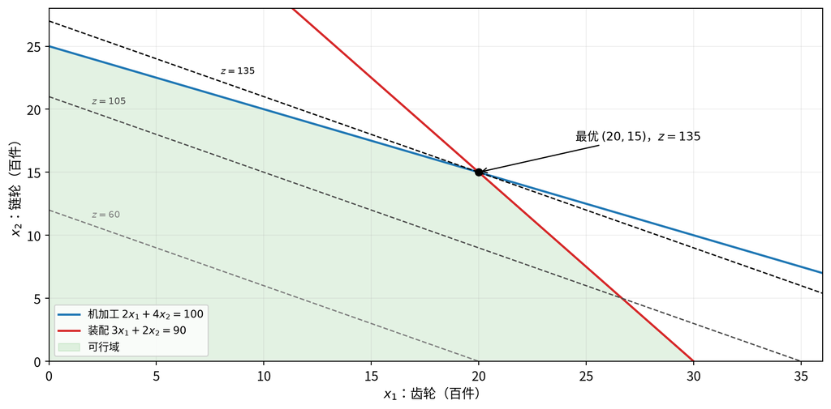

- 绿色区域是两个约束的公共部分；三条虚线是 $z=60/105/135$ 的等值线，斜率都是 $-3/5$
- 最优解落在两条约束的交点 $(20,15)$：再往外推等值线就离开可行域了

**结论：图解法的全部内容就一句——把等值线往外推，最后一个碰到的顶点就是最优解。**

## 运行例子（二）：milp 解 0-1 选型

**原理**：$\max\,p^{\top}x$，s.t. $w^{\top}x\le100$，$x_i\in\{0,1\}$；`milp` 用 `integrality` 标整数、`Bounds(0,1)` 限 0-1

```python
import numpy as np
from scipy.optimize import milp, LinearConstraint, Bounds

p = np.array([55, 45, 40, 32, 28.])    # 年收益（万元）
w = np.array([40, 35, 30, 25, 20.])    # 投资（万元）
cons = LinearConstraint(w[None, :], -np.inf, [100])
res = milp(-p, constraints=cons,
           integrality=np.ones(5), bounds=Bounds(0, 1))
print(res.x, -res.fun)
```

```
[ 1.  1.  0.  1. -0.] 132.0
```

- **结果**：`[1. 1. 0. 1. 0.] 132.0` → 选 1／2／4 号，投资 $40+35+25=100$ 万元、收益 132 万元
- **对照**：松弛解 $(1,0.286,1,0,1)$ 给 135.86 万元，整数解少 3.86 万元——这就是整数间隙
- `integrality` 标整数、`bounds` 收紧成 0-1，两行把“半台设备”挡在模型外

**结论：整数规划只多两行——`integrality` 一开，解就从分数变成可执行的选型。**

## 图：选型结果与预算占用

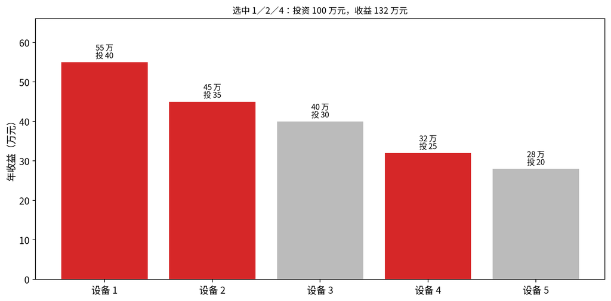

- 红色是三台被选中的设备，灰色是落选；选 3 号（40 万收益／30 万投资）会把预算占满、挤掉收益更高的组合
- 松弛解里 2 号只有 0.286 台、收益 135.86 万元——那 3.86 万元差额就是“不能买半台”的代价

**结论：0-1 选型的图一眼看出取舍——按“每万元投资买多少收益”排序，再看预算能否拼满。**

## 课程代码库（一）：从两变量到产品配比

```python
import numpy as np
from scipy.optimize import linprog

r1 = linprog([-1, 4], A_ub=[[-3, 1], [1, 2]], b_ub=[6, 4],
             bounds=[(None, None), (-3, None)])
print("例1", np.round(r1.x, 2), round(r1.fun, 2))

c = [-1.2, -1.05, -0.75]                # 单位利润（取负求最大）
A = [[0.6, 0.3, 0.0], [0.2, 0.2, 0.4], [0.2, 0.5, 0.6]]
b = [2000, 2500, 1200]
r2 = linprog(c, A_ub=A, b_ub=b, bounds=[(0, None)] * 3)
print("例2", np.round(r2.x, 2), round(-r2.fun, 2))
print("余量", np.round(r2.ineqlin.residual, 2))
```

```
例1 [10. -3.] -22.0
例2 [3333.33    0.    888.89] 4666.67
余量 [   0.   1477.78    0.  ]
```

**结论：LP 的变量数一多，黑板就写不下；代码库的价值是把模型从纸面搬到可复算的脚本。**

## 图：三产品产量与资源利用率

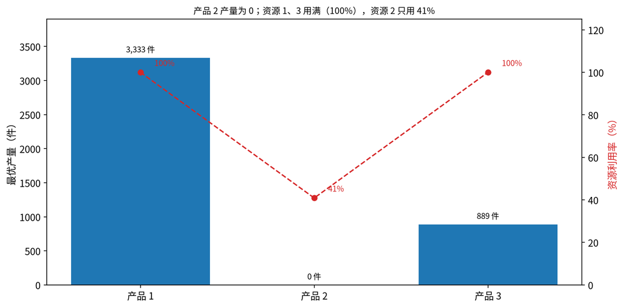

- 产品 2 一根柱子都没有：它的单位资源换来的利润最低，被另外两个产品挤掉
- 资源利用率一眼看出瓶颈：资源 1（100%）与资源 3（100%）是紧约束，资源 2（41%）有富余

**结论：产量柱讲“做什么”，利用率线讲“卡在哪”——两张图一起看才知道该扩哪个资源。**

## 课程代码库（二）：4×6 运输问题，24 个变量

> 上一页到 3 个变量；这一页是代码库里最大的一段——4 个产地、6 个销地，24 个决策变量。
- 数据：供应 76／88／96／40，需求 42／56／44／39／60／59，两边合计都是 300
- 变量 $x_{ij}$ 共 24 个，约束 10 个等式（6 个列和、4 个行和）；改数据只改两个列表，矩阵用推导式拼

```python
import numpy as np
from scipy.optimize import linprog

cost = [500,550,630,1000,800,700, 800,700,600,950,900,930,
        1000,960,840,650,600,700, 1200,1040,980,860,880,780]
sup, dem = [76, 88, 96, 40], [42, 56, 44, 39, 60, 59]
A = [[1 if j == k % 6 else 0 for k in range(24)] for j in range(6)] + \
    [[1 if k // 6 == i else 0 for k in range(24)] for i in range(4)]
r = linprog([-v for v in cost], A_eq=A, b_eq=dem + sup,
            bounds=[(0, max(dem))] * 24)
print("最大利润", round(-r.fun, 1))
print(np.round(r.x.reshape((4, 6)), 0))
```

```
最大利润 284230.0
[[ 0.  0.  6. 39. 31.  0.]
 [ 0.  0.  0.  0. 29. 59.]
 [ 2. 56. 38.  0.  0.  0.]
 [40.  0.  0.  0.  0.  0.]]
```

- 输出：最大利润 **284,230**，分配矩阵 4×6（每行合计＝供应，每列合计＝需求）

**结论：变量一多，建模就变成“拼系数矩阵”的工程活——这也是 LP 走向软件、再走向深度运筹的原因。**

## 图：最优调运矩阵热力图

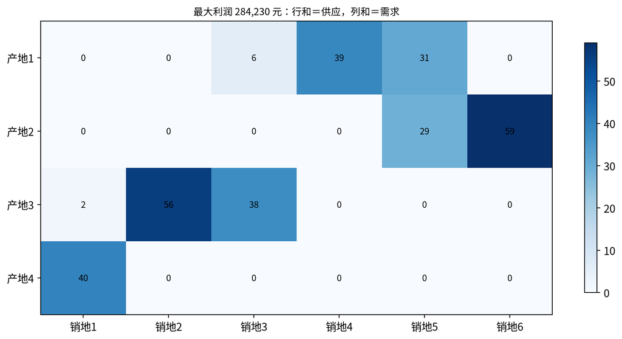

**结论：24 个变量落在纸上是 24 个数，画成热力图才看出“谁给谁供”——这就是可视化的价值。**

## 从 LP 到 GNN：把优化当一层

> 前面把 LP 解透了；这一页回答它和本讲图神经网络、深度运筹怎么接。
- 可微分层：把 $\arg\min$ 当作网络的一层，反传穿过 KKT 条件，就是“端到端优化”
- 排产三段式：GNN 从图上预测工时、换型、需求 → LP/IP 求可行解 → 解回写约束再迭代
- 三个衔接点：图构建（把约束画成图）、系数预测（GNN 估 $A$、$b$、$c$）、解校验（可行性检查）
- 企业要的是**可解释的可行解**，不是黑箱给出的“大概最优”
- 边界：LP/IP 保证最优但要求模型准确；GNN 容噪但无最优性保证——两者互补

**结论：LP 管“算得准”，GNN 管“猜得准”；深度运筹是把两者串成闭环。**

## 深度运筹学框架

| 层次 | 回答 | 工具 |
| --- | --- | --- |
| 运筹学 | 优化什么、受什么约束 | 线性/整数规划、约束规划 |
| 复杂网络 | 谁和谁有关系、关系多强 | 图构建、中心性、群聚 |
| 图深度学习 | 在关系上找模式、找断点 | GCN、GAT、图预测 |

- 运筹学给“目标与约束”，复杂网络给“关系结构”，图学习给“满意解”
- 三者不是串行，是迭代：建图→学习→优化→回写约束
- 输出不是唯一最优，而是可执行、可解释的满意解

## 排产问题图建模

| 图元素 | 排产含义 | 数据来源 |
| --- | --- | --- |
| 节点 | 工单、设备、工序 | ERP/MES 工单与工艺路线 |
| 边 | 工序先后、设备可用 | 工艺路线、设备台账 |
| 边权 | 换型时间、运输时间 | 历史换型记录、标准工时 |
| 节点特征 | 交期、批量、优先级 | 订单与工单主数据 |

- 目标：交期延误、换型次数、在制库存、设备利用率
- 约束：设备能力、工序先后、模具与人员班次
- GNN 预测瓶颈与延期风险，运筹学做局部重排

## 案例：紧急插单的影响半径

- 场景：原排程已满，客户插入一张急单，交期 3 天
- 图上看：急单节点连到哪些设备、工序、物料，影响沿边传播
- GNN 预测受影响工单的延期概率；运筹学只重排受影响子图
- 评价：急单是否按时、其他订单延期多少、换型增加几次

> **插单不是“插进去”就行，要算影响半径。**

## 满意解与最优解

- 最优解：在数学模型里目标最小/最大，通常要精确算法
- 满意解：在可接受时间内、满足约束、足够好的解
- 制造现场约束多、数据噪声大、目标冲突，追求唯一最优不现实
- 深度运筹学的价值：用学习缩小搜索空间，用运筹学保证可行

## 与 APS 的关系

| 层次 | APS 负责 | 深度运筹学补充 |
| --- | --- | --- |
| 排程 | 有限产能排程、插单重排 | 预测瓶颈与延期风险 |
| 优化 | 规则/约束规划求解 | 学习缩小搜索空间 |
| 解释 | 给出排程结果 | 给出关键节点与影响路径 |

- APS 是“执行系统”，深度运筹学是“分析与预测”
- 不要把 GNN 直接当排程器：它输出风险与关系，最终由 APS/运筹学落排程
- 企业落地顺序：先 APS 跑通，再上图学习做增强

## 评价：可解释与可执行

- 可解释：能指出哪些节点/边导致预测，而不是只给一个分数
- 可执行：输出要能落成排程动作、采购动作、维护动作
- 可验证：上线前后用同一口径对比，如延期率、换型次数、在制
- 可维护：换产品、换设备、换班次，模型要能更新

> **企业不买“黑箱最优”，买“能解释、能执行、能验证”的改善。**

## 推导留给 AI：深度运筹学

- 为什么制造系统更适合“满意解”而不是“最优解”？
- 介数中心性高的设备，为什么通常是瓶颈？有没有反例？
- 排产图里，边权用换型时间还是运输时间？两者能相加吗？
- GNN 预测出的延期风险，怎么变成 APS 能执行的约束？

# 第四部分 · PyTorch 实践

- PyTorch 是什么：张量＋自动求导＋神经网络模块
- 训练五件套：数据、模型、损失、优化器、训练循环
- 企业落地：YOLO 缺陷检测、mAP/漏检率/误检率、部署节拍
- 不追框架新特性，先把一个最小例子跑通、讲清

## PyTorch 是什么

> **PyTorch＝张量计算库＋自动求导＋神经网络模块，研究者和工业界都用。**
- 张量（Tensor）：GPU 上的多维数组，和 NumPy 类似但能自动求导
- 自动求导：前向记录计算图，反向自动算梯度
- `nn.Module`：把层和参数封装成模型；`optim`：优化器；`DataLoader`：批量加载
- 动态图：写起来像普通 Python，调试方便

## 环境：Anaconda 与虚拟环境

- Anaconda 管理 Python 与包；每个项目一个独立环境，避免版本冲突
- 常用命令：
  - `conda create -n yolo python=3.10`
  - `conda activate yolo`
  - `pip install torch torchvision`
- 环境要写进 `requirements.txt`，保证别人能复现
- 企业里还要固定 CUDA 驱动版本，避免“换台机器就跑不起来”

## 安装与检查 GPU

- 官网按“系统＋包管理＋CUDA 版本”生成安装命令，不要手拼
- 检查：
  - `import torch`
  - `torch.__version__`
  - `torch.cuda.is_available()`
- 返回 `True` 才说明 GPU 可用；否则回退 CPU，训练会慢很多
- 显存不够时减小 batch size、输入尺寸，或改用混合精度

## 张量：PyTorch 的基本单位

```python
import torch
x = torch.tensor([[1.0, 2.0], [3.0, 4.0]])
y = torch.randn(2, 3)          # 标准正态
z = x @ x.t()                  # 矩阵乘
print(x.shape, z)
```

- 形状（shape）、数据类型（dtype）、设备（device）是三件必须检查的事
- 张量运算要形状匹配；批量维通常放第 0 维
- 迁移设备：`x.to('cuda')`；模型也要 `.to('cuda')`

## Dataset 与 DataLoader

- `Dataset`：定义“一条样本怎么读”，实现 `__len__` 与 `__getitem__`
- `DataLoader`：批量、打乱、并行加载，输出 batch
- 训练集打乱，验证/测试集不打乱，保证结果可复现
- 企业数据要检查：类别分布、重复样本、标注一致性

## 模型：nn.Module

```python
import torch.nn as nn
model = nn.Sequential(
    nn.Linear(10, 32), nn.ReLU(),
    nn.Linear(32, 5)
)
```

- `nn.Sequential` 适合简单堆叠；复杂模型继承 `nn.Module` 写 `forward`
- 输出维度要跟任务对齐：5 类缺陷就是 5 维 logits
- 模型初始化、参数量、是否预训练，都要在报告里写清

## 损失函数：任务决定损失

| 任务 | 损失 | 说明 |
| --- | --- | --- |
| 二分类 | BCEWithLogitsLoss | 输出 logit，数值稳定 |
| 多分类 | CrossEntropyLoss | 内部做 softmax |
| 回归 | MSELoss / L1Loss | 大误差敏感/鲁棒 |
| 检测 | 分类损失＋框回归损失 | YOLO 自带组合损失 |

- 损失要和评价指标一致：漏检代价高，就在损失里给正类更高权重
- 类别不均：用加权交叉熵、Focal Loss 或重采样
- 不要手写 softmax 再进 CrossEntropyLoss，会重复计算

## 优化器与学习率

- SGD：带动量，泛化好，调参慢
- Adam/AdamW：自适应学习率，收敛快，常用默认
- 学习率是最重要的超参数：太大震荡，太小太慢
- 策略：预热（warmup）、阶梯衰减、余弦退火

> **先固定其他超参数，只调学习率，看损失曲线。**

## 训练循环：五步

```python
for epoch in range(epochs):
    model.train()
    for xb, yb in train_loader:
        pred = model(xb)              # 1 前向
        loss = criterion(pred, yb)    # 2 损失
        optimizer.zero_grad()         # 3 清梯度
        loss.backward()               # 4 反向
        optimizer.step()              # 5 更新
```

- 顺序不能错：清梯度要在反向之前
- 每个 epoch 后在验证集上评估，保存最优权重
- 记录训练/验证损失、学习率、耗时

## 验证与早停

- 验证集不参与训练，只用于选模型与调超参数
- 早停：验证损失连续 $N$ 轮不降就停，防止过拟合
- 保存最优权重，不保存最后一轮
- 测试集只在最终评估用一次，不能反复调

## TensorBoard：看训练过程

- 记录：损失、学习率、验证指标、权重直方图、样例图像
- 启动：`tensorboard --logdir runs`
- 看三条曲线：训练损失、验证损失、验证指标
- 训练损失降、验证损失升＝过拟合；两条都平＝学习率太小或模型太弱

## YOLO 训练流程

1. 数据：图像＋标注框，按 YOLO 格式组织 `images/`、`labels/`
2. 配置：类别数、输入尺寸、batch、epoch、预训练权重
3. 训练：`yolo detect train data=... model=... epochs=...`
4. 评估：验证集算 mAP50、mAP50-95、各类别 P/R
5. 导出：ONNX/TensorRT，测推理节拍

## 数据增强与迁移学习

- 数据增强：翻转、旋转、缩放、裁剪、亮度/对比度、噪声、马赛克
- 增强要符合现场：齿轮缺陷不能随便翻转导致纹理失真
- 迁移学习：用 COCO/ImageNet 预训练权重，小样本也能收敛
- 先冻结 backbone 训练头，再解冻微调，学习率调小

## 学习率余弦退火

$$\eta_t=\eta_{\min}+\frac12(\eta_{\max}-\eta_{\min})\left(1+\cos\frac{t\pi}{T}\right)$$

- $\eta_t$ 为第 $t$ 步学习率，$T$ 为周期，$\eta_{\max}/\eta_{\min}$ 为上下界
- 前期大学习率快速下降，后期小学习率精细收敛
- 变周期版本可多次退火，跳出局部最优
- 要和 warmup 配合：前几百步线性升温，避免早期震荡

## 评价：mAP、漏检率、误检率

| 指标 | 定义 | 企业含义 |
| --- | --- | --- |
| mAP50 | IoU≥0.5 时各类 AP 的平均 | 检测准不准 |
| 漏检率 | $FN/(TP+FN)$ | 坏件被放过的比例 |
| 误检率 | $FP/(FP+TN)$ | 好件被误判的比例 |
| 节拍 | 单件推理时间（s/件） | 产线能不能跟上 |

- mAP 是学术指标，漏检率/误检率才是企业验收指标
- 两者可能背离：mAP 高但小缺陷漏检多
- 报告必须同时给混淆矩阵、各类别指标和失败样本

## 企业案例：齿轮缺陷检测的验收

- 数据：约 2000 张、5 类；划痕、磕碰、缺齿、锈蚀、正常
- 目标：漏检率≤1%、误检率≤3%、单件≤2 s
- 做法：YOLO 预训练＋数据增强＋余弦退火；按类别看 P/R
- 结果口径：先报混淆矩阵，再报漏检/误检/节拍，最后给 3 个失败样本
- 若漏检不达标：先查标注与数据分布，再查阈值与模型，不要只调参

## 部署与节拍

- 导出：ONNX、TensorRT、OpenVINO；按硬件选
- 量化：FP16/INT8，提速但可能掉精度，要重新验收
- 节拍：预处理＋推理＋后处理的总时间，不只是模型前向
- 现场：光照、相机、工件姿态变化，要在产线上复测

> **实验室 mAP 不等于产线节拍，验收必须在现场。**

## 常见错误与 AI 复核

| 错误 | 后果 | 纠正 |
| --- | --- | --- |
| 训练/测试混用 | 指标虚高 | 严格划分，测试只用一次 |
| 类别不均不看混淆矩阵 | 漏检被平均掉 | 按类别报 P/R |
| 只调参不看数据 | 标注错误学进去 | 先查标注一致性 |
| AI 生成代码不核对 | 形状/设备错误 | 逐行解释并跑通小例子 |

- AI 可以帮你写代码、查报错，但不能替你判断数据与指标
- 每段 AI 代码都要能说清输入输出、形状、设备
- 报告附“AI 使用说明”：用它做了什么、人工改了什么

## 推导留给 AI：PyTorch 实践

- 为什么交叉熵损失内部已经做了 softmax，不能再手动加一层？
- 验证损失开始上升时，应该保存哪一轮的权重？为什么？
- 余弦退火的周期 $T$ 设得太长或太短，分别会怎样？
- 模型在实验室 mAP 很高、产线漏检却超标，排查顺序是什么？

# 第五部分 · 例题、讨论与 AI 提问

- 例题一：混淆矩阵与漏检率/误检率
- 例题二：算法选型（传统特征＋SVM 与 YOLO）
- 讨论：小样本、标注质量与验收口径
- 每个例题先自己做，再看解答

## 例题一：混淆矩阵与漏检率 —— 题干

**背景**：某批 1000 件齿轮，其中 100 件有缺陷。模型报出 102 件缺陷，其中 96 件确实是缺陷；另有 4 件缺陷未报出。

**求**：① TP、FP、FN、TN；② 精确率、召回率、F1；③ 漏检率、误检率；④ 是否达到“漏检≤1%、误检≤3%”。

- 提示：先画 2×2 混淆矩阵，再代公式
- 注意：误检率分母是“实际正常件数”

## 例题一：混淆矩阵与漏检率 —— 解答

|  | 预测缺陷 | 预测正常 | 合计 |
| --- | --- | --- | --- |
| 实际缺陷 | TP＝96 | FN＝4 | 100 |
| 实际正常 | FP＝6 | TN＝894 | 900 |

- 精确率 $P=96/102=94.1\%$；召回率 $R=96/100=96.0\%$；$F1=2PR/(P+R)=95.0\%$
- 漏检率 $=FN/(TP+FN)=4/100=4.0\%$；误检率 $=FP/(FP+TN)=6/900=0.67\%$
- **判读**：误检率 0.67% 达标（≤3%），漏检率 4.0% 不达标（≤1%），先查 4 件漏检的类别与标注

## 例题二：算法选型 —— 题干

**背景**：企业齿轮缺陷数据 2000 张、5 类，要求漏检≤1%、单件≤2 s；现有工控机无独立 GPU。

**候选**：A 传统特征＋SVM；B YOLO＋GPU 服务器；C 轻量 CNN＋边缘盒子。

**求**：从数据、精度、节拍、部署、维护五个维度比较，给出推荐与理由。

- 提示：先排除不满足硬约束的方案，再比软指标
- 注意：无 GPU 是硬约束，不能假设“以后会买”

## 例题二：算法选型 —— 参考结论

| 维度 | A 特征＋SVM | B YOLO＋GPU | C 轻量 CNN＋边缘 |
| --- | --- | --- | --- |
| 数据 | 几百张可起步 | 2000 张够 | 2000 张偏少 |
| 精度 | 中，小缺陷弱 | 高 | 中高 |
| 节拍 | 快 | 快（需 GPU） | 快（边缘） |
| 部署 | 工控机可跑 | 要买 GPU 服务器 | 边缘盒子可跑 |
| 维护 | 换产品重设特征 | 重标注训练 | 重标注训练 |

- 硬约束“无 GPU”排除 B；A 精度不足、维护差；推荐 C 轻量 CNN＋边缘盒子
- 若后续允许 GPU，再评估 B；先小批量试点，按漏检率与节拍验收
- 结论要写清假设与风险，不能只写“推荐 C”

## 讨论：小样本、标注与验收口径

- 小样本：先迁移学习＋数据增强，再考虑半监督/合成数据；不要一上来堆模型
- 标注：定类别边界、双人标注、抽检一致率；不一致的样本退回重标
- 验收：漏检率、误检率、节拍三项写进合同；测试集要覆盖新批次、新光照
- 伦理：员工影像、客户图纸、缺陷数据的权限与保存期限

## 推导留给 AI：例题与讨论

- 漏检率 4% 但误检率 0.67%，应该先调阈值还是先查数据？为什么？
- 无 GPU 的产线，轻量 CNN 与“传统特征＋SVM”哪个更适合长期维护？
- 测试集只覆盖老批次，验收通过后上线会出什么问题？
- 如果企业要求“零漏检”，技术上该怎么回答？

# 第六部分 · 本讲小结、作业与下讲预告

- 小结：算法—图—运筹—落地四句话
- 作业：手算 GCN、训练模型、图建模、选型报告
- 企业真题：齿轮缺陷检测的验收报告
- 下讲：第 6 章 8D 与课程设计

## 本讲小结：四句话

1. **算法**：先定任务与指标，再选模型；传统方法是基线，深度学习不是万能
2. **图**：制造问题多是关系问题；节点、边、权重定对了，GNN 才有意义
3. **运筹**：运筹学定目标与约束，复杂网络建关系，图学习找满意解
4. **落地**：mAP 不等于漏检率；验收看漏检、误检、节拍，报告要能解释

> **方法的价值不在“新”，在“能落到企业指标上”。**

## 作业：四道题

| 序号 | 类型 | 题目 |
| --- | --- | --- |
| 1 | 手算 | 给定 4 节点图与特征，手算一层 GCN，写出归一化邻接矩阵与聚合结果 |
| 2 | 代码 | 用企业脱敏缺陷数据训练 YOLO，报 mAP、漏检率、误检率与单件推理时间 |
| 3 | 建模 | 把企业排产问题画成图，说明节点、边、权重、约束与目标 |
| 4 | 选型 | 比较传统特征＋SVM、YOLO、轻量 CNN 三方案，给出推荐与假设 |

- 四题分别对应算法、图、运筹、落地四个内容块
- 第 2 题必须附混淆矩阵与 3 个失败样本分析
- 第 3、4 题要写清企业数据来源与验收口径

## 企业真题作业：齿轮缺陷检测验收报告

- 数据：企业脱敏齿轮缺陷图像（约 2000 张、5 类）
- 指标：漏检率≤1%、误检率≤3%、单件≤2 s
- 报告结构：问题—数据—方法—混淆矩阵—失败样本—结论与改进
- 评分：数据与标注 20%、方法与实验 30%、指标与结论 30%、表达与伦理 20%
- 提交：代码＋报告＋AI 使用说明；优秀样本进课程档案

## 下讲预告：第 6 章 8D 与课程设计

- 第 6 章：8D 八步，从 D0 到 D8；用企业客诉走一遍
- 课程设计：企业零件缺陷智能评测，8D 作为报告骨架
- 本讲的方法进入课程设计：模型、指标、失败样本分析
- 预习：读一份企业 8D 报告，找出 D4 与 D7 的证据

## 谢谢：把方法带回产线

> **算法是工具，图是视角，运筹是约束，验收是底线。**
- 课后先跑通最小例子，再谈模型改进
- 企业数据先查标注与分布，再调参
- 任何结论都要能回答：漏检多少、误检多少、节拍够不够